# TCS TACTICS Submission

Chitresh Pandey

Monday, February 09, 2015

Description of the various fields in the CSV data file(s) for the TACTiCS IoT Analytics Challenge

Data given in the csv files is collected from TCS buses plying in the city of Chennai. The data has been logged when the buses operate to pick-up and drop-off associates during the morning and evening times. This data has been collected by installing GPS and other relevant sensors inside a sub-set of TCS buses. Data in one CSV file corresponds to sensory data collected from one bus.

. time_stamp - This is the timestamp with time zone defined. So please ignore +5:30 as all of them are in India timezone only. . procedure_id - The full name of the sensor . feature_of_interest_id -The device ID on which the sensor is attached. . phenomenon_id - The full name of the sensor features. It will be one of the following four features: I. Route ID - The route on which that particular bus was travelling II. JourneyDirection - It will be either “Pickup” or “Drop” III. Location - The Longitude and latitude value of the bus’s GPS position at that point of time IV. Speed - The speed obtained from GPS sensors (miles/hour) . offering_id - No significance as the value is same for all . text_value - The string containing either RouteID or Journey Direction . numeric_value - The speed in miles per hour . st_astext - The longitude value followed by latitude value  
. mime_type - No significance as the value is same for all . observation_id - An ever increasing value only required for database sanity check

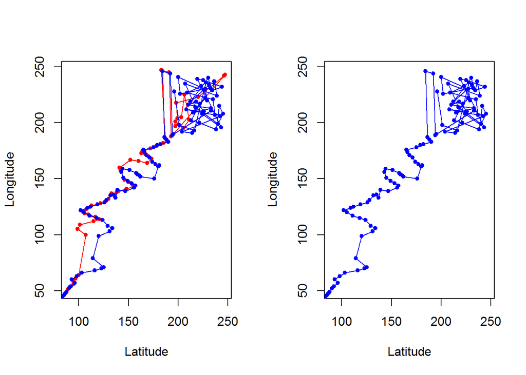

```r
# setwd("C:/CHITRESH - DUMPS/TCS DATA ANALYTICS CHALLENGE")
# install.packages("maptools")
# library(maptools)


TCSBUSDATA <- read.csv("./sample-Siruseri-Bus-data.csv")

TCSBUSDATA$time_stamp <- as.POSIXlt(TCSBUSDATA$time_stamp)
levels(TCSBUSDATA$procedure_id) <- "Bus:00409DFF-FF581762"
levels(TCSBUSDATA$feature_of_interest_id) <- "00409DFF-FF581762"
levels(TCSBUSDATA$phenomenon_id) <- c("JourneyDirection" , "Location" , "RouteID" , "Speed")
TCSBUSDATA <- TCSBUSDATA[ ,-5]


gps_data <- (TCSBUSDATA$st_astext)
gps_data <- as.character(gps_data)
indexNA <- is.na(gps_data)
gps_data[!indexNA] <- substring(as.character(gps_data[!indexNA]) , first = 7 , last = nchar(as.character(gps_data[!indexNA])  , type = "chars" , allowNA = FALSE)-1)


longitude <- character(length = 0)
latitude <- character(length = 0)

for(count in 1:length(gps_data))
{
        if ( !is.na(gps_data[count]))
        {
                longitude[count] <-  strsplit(gps_data[count], split = " " , fixed = TRUE)[[1]][1]
                latitude[count]  <-  strsplit(gps_data[count], split = " " , fixed = TRUE)[[1]][2]
        }

        else
        {
                longitude[count] <- "NA"
                latitude[count] <- "NA"

        }


}

TCSBUSDATA <- transform( TCSBUSDATA , longitude = longitude , latitude = latitude )
TCSBUSDATA <- TCSBUSDATA[ ,-7]



long_data <- longitude[!is.na(longitude)]
lat_data <- latitude[!is.na(latitude)]

names(TCSBUSDATA) <- c("TimeStamp" , "ProcedureID" , "FeatureOfIntres" , "PhenomenonID" , "TextValue" , "NumericValue" ,"Longitude" ,"Latitude" )

workdata <- TCSBUSDATA[, -c(2,3)]
Jan21 <- workdata[ indexJan21 <- workdata$TimeStamp < "2014-01-22" , ]
Jan22 <- workdata[ indexJan22 <- workdata$TimeStamp > "2014-01-22" & workdata$TimeStamp < "2014-01-23",]


## As  Character
long_data_Jan21 <- as.character(Jan21$Longitude[!is.na(Jan21$Longitude)])
lat_data_Jan21 <- as.character(Jan21$Latitude[!is.na(Jan21$Latitude)])

long_data_Jan22 <- as.character(Jan22$Longitude[!is.na(Jan22$Longitude)])
lat_data_Jan22 <- as.character(Jan22$Latitude[!is.na(Jan22$Latitude)])

## As Numeric
long_data_Jan21 <- as.numeric(Jan21$Longitude[!is.na(Jan21$Longitude)])
lat_data_Jan21 <- as.numeric(Jan21$Latitude[!is.na(Jan21$Latitude)])

long_data_Jan22 <- as.numeric(Jan22$Longitude[!is.na(Jan22$Longitude)])
lat_data_Jan22 <- as.numeric(Jan22$Latitude[!is.na(Jan22$Latitude)])


par(mfrow = c(1,2))

plot(lat_data_Jan21 ,long_data_Jan21 , pch = 20 , col = "red" , xlab = "Latitude" , ylab = "Longitude" )
lines(lat_data_Jan21 ,long_data_Jan21 ,  lwd = 1 , col = "red")
points( lat_data_Jan22 ,long_data_Jan22 , pch = 20 , col = "blue")
lines(lat_data_Jan22 , long_data_Jan22 , lwd = 1 , col = "blue")



## plot(long_data_Jan22 , lat_data_Jan22 , pch = 20 )

plot(lat_data_Jan21 ,long_data_Jan21 , pch = 20 , col = "red" , xlab = "Latitude" , ylab = "Longitude" , type = "n")
points( lat_data_Jan22 ,long_data_Jan22 , pch = 20 , col = "blue")
lines(lat_data_Jan22 , long_data_Jan22 , lwd = 1 , col = "blue")
```

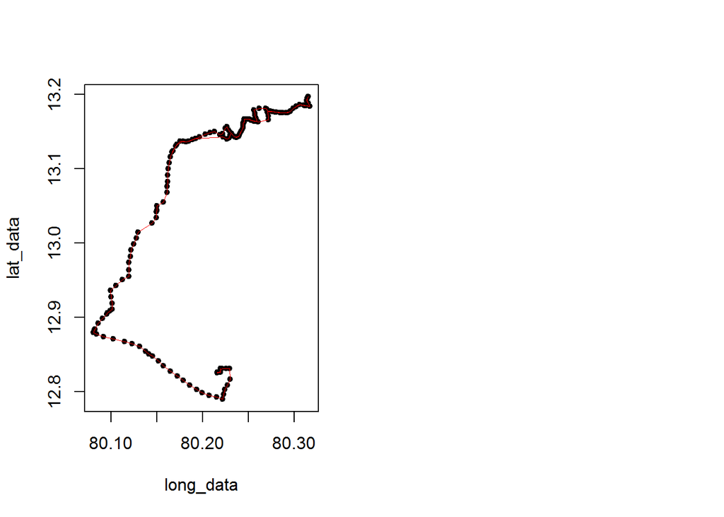

```r
## Plotting Longitude and Latitude Data
plot(long_data , lat_data , pch = 20 )
lines(long_data , lat_data , lwd = 0.5 , col = "red")




##
### Staging Area
# substr("abcdef", 2, 4)
# substring("abcdef", 1:6, 1:6)
# substring("urn:ogc:def:phenomenon:OGC:1.0.30:Location" , 35 , 42)

# teststr <- "urn:ogc:def:phenomenon:OGC:1.0.30:Location"
## /* Staging Area
# substring(teststr, 35 , nchar(teststr , type = "chars" , allowNA = FALSE))


# strsplit("80.2193166667 12.8267731667" , split = " " , fixed = TRUE)[[1]][1]
```